# Projet Analyse statistique

Aloui Ameni

2024-09-17

Dans ce projet, nous allons etudier les differents facteurs qui peuvent engendrer la présence de maladie de coeur. pour cela, on a utiliser le jeu de données “heart” qui a été collecté auprès d’un échantillon de patients.

1-Importation et exploration des données R:

```r
db=read.table(file=file.choose(),header =TRUE,sep = "\t", dec ='.')
View(db)
str(db)
```

```
## 'data.frame':    270 obs. of  13 variables:
##  $ age         : int  70 67 57 64 74 65 56 59 60 63 ...
##  $ sexe        : chr  "masculin" "feminin" "masculin" "masculin" ...
##  $ type_douleur: chr  "D" "C" "B" "D" ...
##  $ pression    : int  130 115 124 128 120 120 130 110 140 150 ...
##  $ cholester   : int  322 564 261 263 269 177 256 239 293 407 ...
##  $ sucre       : chr  "A" "A" "A" "A" ...
##  $ electro     : chr  "C" "C" "A" "A" ...
##  $ taux_max    : int  109 160 141 105 121 140 142 142 170 154 ...
##  $ angine      : chr  "non" "non" "non" "oui" ...
##  $ depression  : num  2.4 1.6 0.3 0.2 0.2 0.4 0.6 1.2 1.2 4 ...
##  $ pic         : int  2 2 1 2 1 1 2 2 2 2 ...
##  $ vaisseau    : chr  "D" "A" "A" "B" ...
##  $ coeur       : chr  "presence" "absence" "presence" "absence" ...
```

2-Etude des variables « electro et coeur»:

Cette partie traite les deux variables qualitatives electro et coeur.

```r
#Variable Coeur
levels(as.factor(db$coeur))
```

```
## [1] "absence"  "presence"
```

```r
eff_coeu=table(db$coeur)
eff_coeu
```

```
##
##  absence presence
##      150      120
```

```r
feq_coeu=eff_coeu/length(db$coeur)
feq_coeu
```

```
##
##   absence  presence
## 0.5555556 0.4444444
```

```r
#Variable Electro
levels(as.factor(db$electro))
```

```
## [1] "A" "B" "C"
```

```r
eff_elec=table(db$electro)
eff_elec
```

```
##
##   A   B   C
## 131   2 137
```

```r
feq_elec=prop.table(eff_elec)
feq_elec
```

```
##
##           A           B           C
## 0.485185185 0.007407407 0.507407407
```

**Représentation Graphique « electro et coeur»**

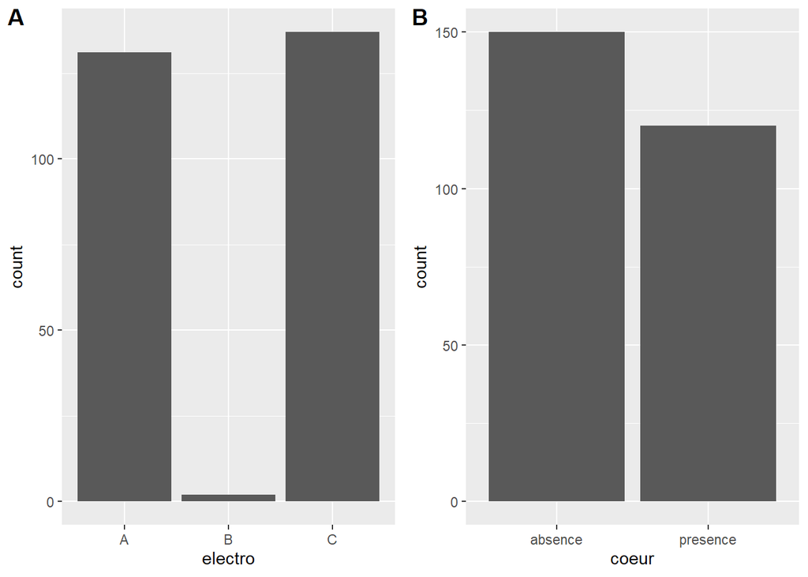

```r
library(ggplot2)
library(cowplot)
db1 <- ggplot(db) + aes(x = electro) + geom_bar()
db2 <- ggplot(db) + aes(x = coeur) + geom_bar()

plot_grid(db1, db2, labels = "AUTO")
```

**Croisement entre «electro et coeur»** *tableau de contingence

```r
tabcont=table(db$electro,db$coeur)
tabcont
```

```
##
##     absence presence
##   A      85       46
##   B       1        1
##   C      64       73
```

**Représentation Graphique du croissement**

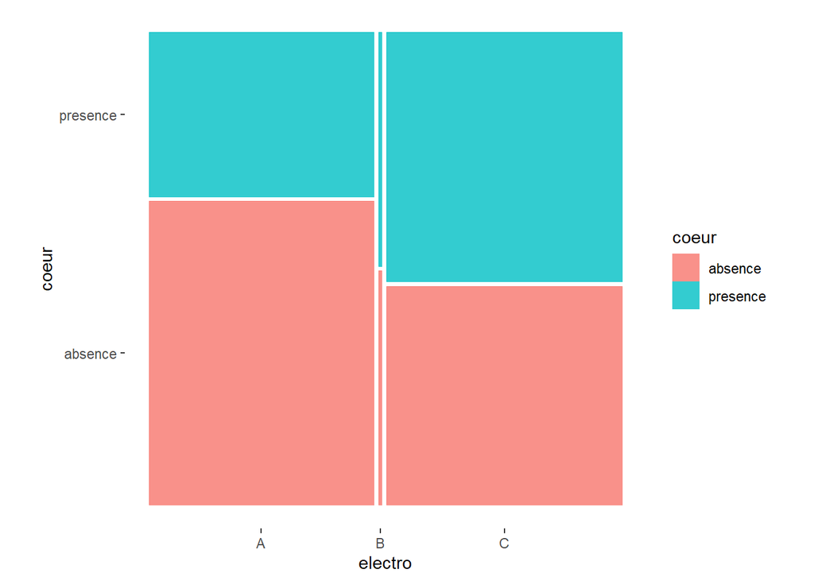

```r
library(ggmosaic)
ggplot(data = db) +
  geom_mosaic(aes(x = product(electro), fill = coeur)) +
  theme_mosaic()
```

```r
chisq.test(tabcont)
```

```
##
##  Pearson's Chi-squared test
##
## data:  tabcont
## X-squared = 8.9795, df = 2, p-value = 0.01122
```

on compare la valeur de p-value obtenue à 5% (0.05) la valeur de p-value obtenue est 0.01122, il est donc très largement inférieur à 5% , d’ou il existe une difference significative entre le type de coeur et le type de electro. Ces deux variables dépendent l’une de l’autre.

2-Etude des variables « age et cholesterol »:

```r
mean(db$age)
```

```
## [1] 54.43333
```

```r
mean(db$cholester)
```

```
## [1] 249.6593
```

```r
median(db$age)
```

```
## [1] 55
```

```r
median(db$cholester)
```

```
## [1] 245
```

```r
min(db$age)
```

```
## [1] 29
```

```r
min(db$cholester)
```

```
## [1] 126
```

```r
quantile(db$age)
```

```
##   0%  25%  50%  75% 100%
##   29   48   55   61   77
```

```r
quantile(db$cholester)
```

```
##   0%  25%  50%  75% 100%
##  126  213  245  280  564
```

```r
max(db$age)
```

```
## [1] 77
```

```r
max(db$cholester)
```

```
## [1] 564
```

```r
var(db$age)
```

```
## [1] 82.97509
```

```r
var(db$cholester)
```

```
## [1] 2671.467
```

```r
sd(db$age)
```

```
## [1] 9.109067
```

```r
sd(db$cholester)
```

```
## [1] 51.68624
```

```r
cv1=sd(db$age)/mean(db$age)
cv1
```

```
## [1] 0.1673435
```

```r
cv2=sd(db$cholester)/mean(db$cholester)
cv2
```

```
## [1] 0.2070271
```

*Representation graphique de la variable age*

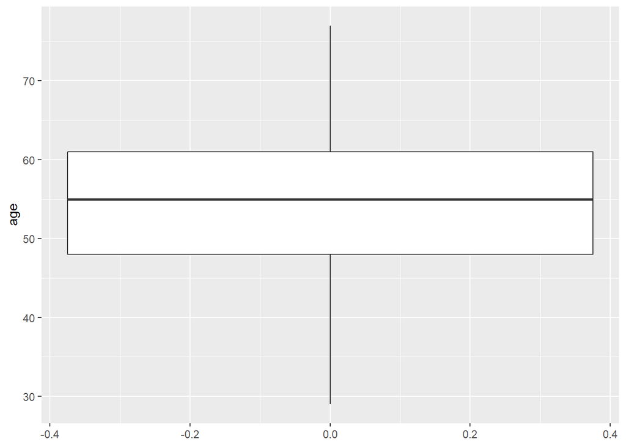

```r
ggplot(db)+aes(y=age) + geom_boxplot()
```

**Representation garphique de la variable cholester**

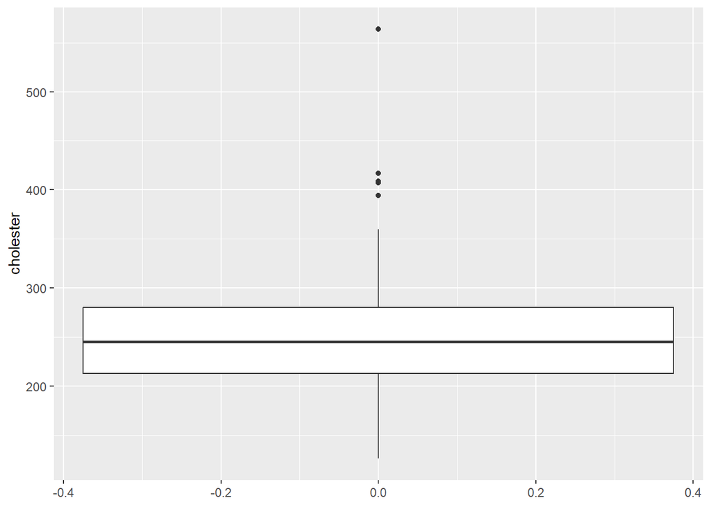

```r
ggplot(db)+aes(y=cholester) + geom_boxplot()
```

On observe une distribution approxiatiquement symetrique de la variable age et chlestel. En effet, la ligne mediane est devie au centre de la boîte à moustaches par rapport à la longueur de la boîte. de plus, la longueur de la moustache supérieure est approximatiquement agale a la longueur de la moustache inférieure

*Regroupemnt de a variable age en classes age*

```r
n=length(db$age)
classeage=cut(db$age,breaks=(1+3.3*log10(n)))
table(classeage)
```

```
## classeage
##   (29,34.3] (34.3,39.7]   (39.7,45]   (45,50.3] (50.3,55.7]   (55.7,61]
##           3           9          44          30          52          67
##   (61,66.3] (66.3,71.7]   (71.7,77]
##          41          21           3
```

```r
range(db$age)
```

```
## [1] 29 77
```

```r
length(db$age)
```

```
## [1] 270
```

On a cree 9 classes d’age. Pour cela, on a utilisee la regle de sturges:1+3.3logN=1+(3.3*log270)=9.

*Relation entre les deux variables*

```r
cov(db$age,db$cholester)
```

```
## [1] 103.6055
```

```r
cor(db$age,db$cholester)
```

```
## [1] 0.2200563
```

cov ( X, Y)=103.6 > 0 : d’ou il existe une dépendance linéaire positive entre les deux variables age et cholester. Autrement dit les deux variables varient dans le meme sens. on note un coefficient de coorelation egale a 0.22. les deux variables age et cholester sont positivement et faiblement coorele. Plus les individues sont agees, plus le niveau de scholester augmente.

*nuage de points*

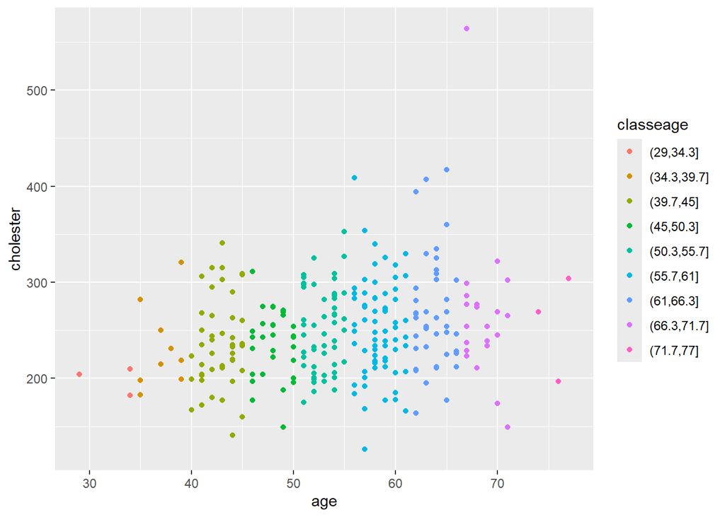

```r
ggplot(db)+aes(x=age,y=cholester,color=classeage)+geom_point()
```

le graphiqe montre correlation positive entre les deux variables. Il suggere une relation linaire croissante.

*Modélisation linéaire simple*

On cherche à expliquer la variation du cholester par rapport a l’age.

```r
reg=lm(db$cholester~db$age)
reg
```

```
##
## Call:
## lm(formula = db$cholester ~ db$age)
##
## Coefficients:
## (Intercept)       db$age
##     181.692        1.249
```

```r
coef(reg)
```

```
## (Intercept)      db$age
##  181.691994    1.248633
```

```r
eq1=paste('cholester~', round((coef(reg)[1]),2),'+',round((coef(reg)[2]),3),'*age')
```

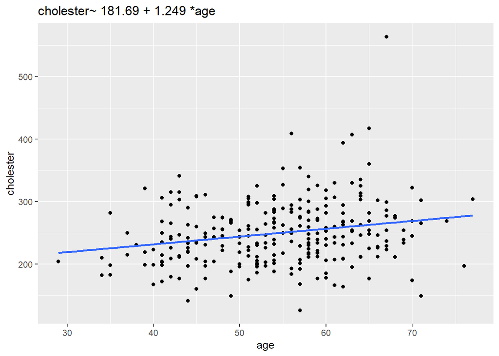

```r
ggplot(db)+aes(x=age,y=cholester)+geom_point()+stat_smooth(method="lm", se=FALSE)+
  ggtitle(eq1)
```

4-Etude des variables « type_douleur et pression»

```r
mean(db$pression)
```

```
## [1] 131.3444
```

```r
median(db$pression)
```

```
## [1] 130
```

```r
quantile(db$pression)
```

```
##   0%  25%  50%  75% 100%
##   94  120  130  140  200
```

```r
min(db$pression)
```

```
## [1] 94
```

```r
max(db$pression)
```

```
## [1] 200
```

```r
names(which.max(table(db$pression)))
```

```
## [1] "120"
```

*representation garphique de la variable pression*

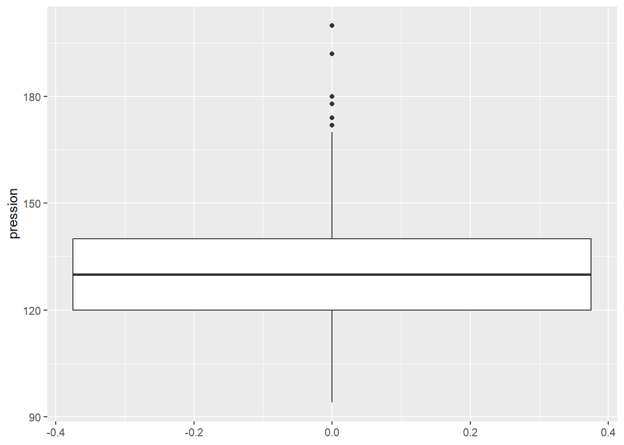

```r
ggplot(db)+aes(y=pression) + geom_boxplot()
```

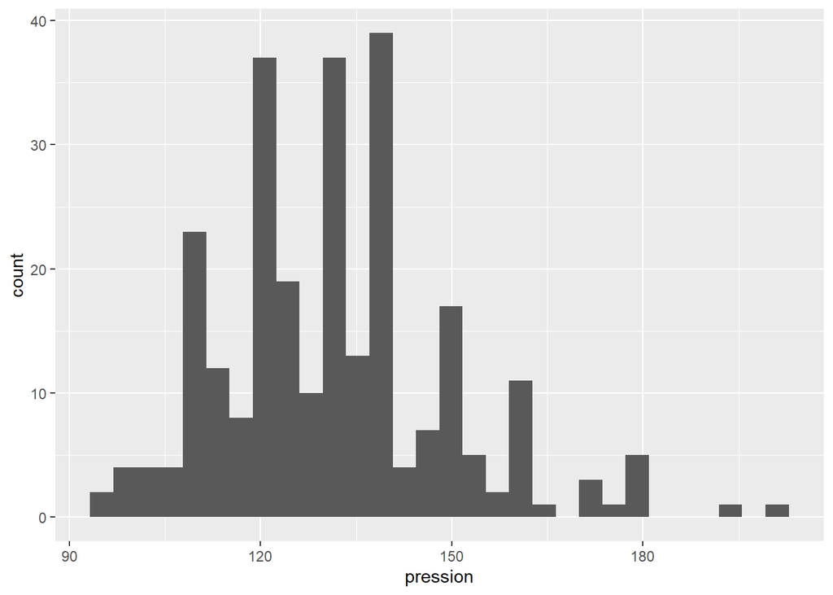

```r
ggplot(db)+aes(x=pression)+geom_histogram()
```

*Test ANOVA*

```r
db$type_douleur <- as.factor(db$type_douleur)
test <- aov(pression ~ type_douleur, data = db)
test
```

```
## Call:
##    aov(formula = pression ~ type_douleur, data = db)
##
## Terms:
##                 type_douleur Residuals
## Sum of Squares       2673.46  83147.50
## Deg. of Freedom            3       266
##
## Residual standard error: 17.68006
## Estimated effects may be unbalanced
```

```r
summary(test)
```

```
##               Df Sum Sq Mean Sq F value Pr(>F)
## type_douleur   3   2673   891.2   2.851 0.0378 *
## Residuals    266  83148   312.6
## ---
## Signif. codes:  0 '***' 0.001 '**' 0.01 '*' 0.05 '.' 0.1 ' ' 1
```

Les résultats de l’ANOVA montrent une relation statistiquement significative entre les types de douleur (type_douleur) et la pression artérielle (pression). Avec une statistique F de 2,851 et une p-value de 0,0378, il y a moins de 5 % de chances que cette différence soit due au hasard. Cela suggère que les différents types de douleur ont un impact notable sur la pression artérielle, justifiant ainsi une exploration plus approfondie de cette relation dans le cadre médical.

5-Modélisation linéaire de la variable « pression en fonction de la variable cholesterol »:

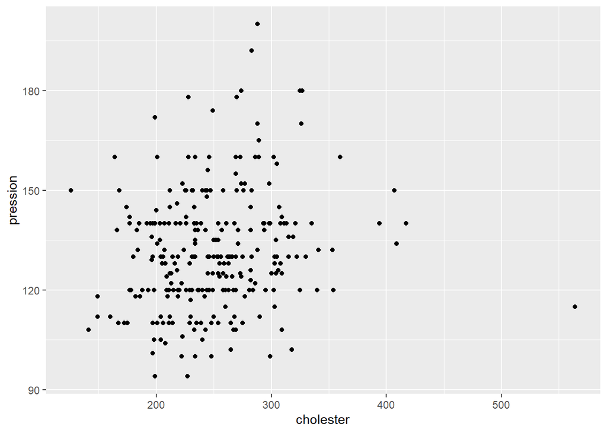

```r
ggplot(db)+aes(x=cholester,y=pression)+geom_point()
```

```r
reg2=lm(db$pression~db$cholester)
reg2
```

```
##
## Call:
## lm(formula = db$pression ~ db$cholester)
##
## Coefficients:
##  (Intercept)  db$cholester
##    116.41693       0.05979
```

```r
summary(reg)
```

```
##
## Call:
## lm(formula = db$cholester ~ db$age)
##
## Residuals:
##      Min       1Q   Median       3Q      Max
## -126.864  -34.233   -3.756   28.697  298.650
##
## Coefficients:
##             Estimate Std. Error t value Pr(>|t|)
## (Intercept) 181.6920    18.6593   9.737  < 2e-16 ***
## db$age        1.2486     0.3381   3.693 0.000269 ***
## ---
## Signif. codes:  0 '***' 0.001 '**' 0.01 '*' 0.05 '.' 0.1 ' ' 1
##
## Residual standard error: 50.51 on 268 degrees of freedom
## Multiple R-squared:  0.04842,    Adjusted R-squared:  0.04487
## F-statistic: 13.64 on 1 and 268 DF,  p-value: 0.0002686
```

```r
eq2=paste('pression~', round((coef(reg2)[1]),2),'+',round((coef(reg2)[2]),3),'*cholester')
eq2
```

```
## [1] "pression~ 116.42 + 0.06 *cholester"
```

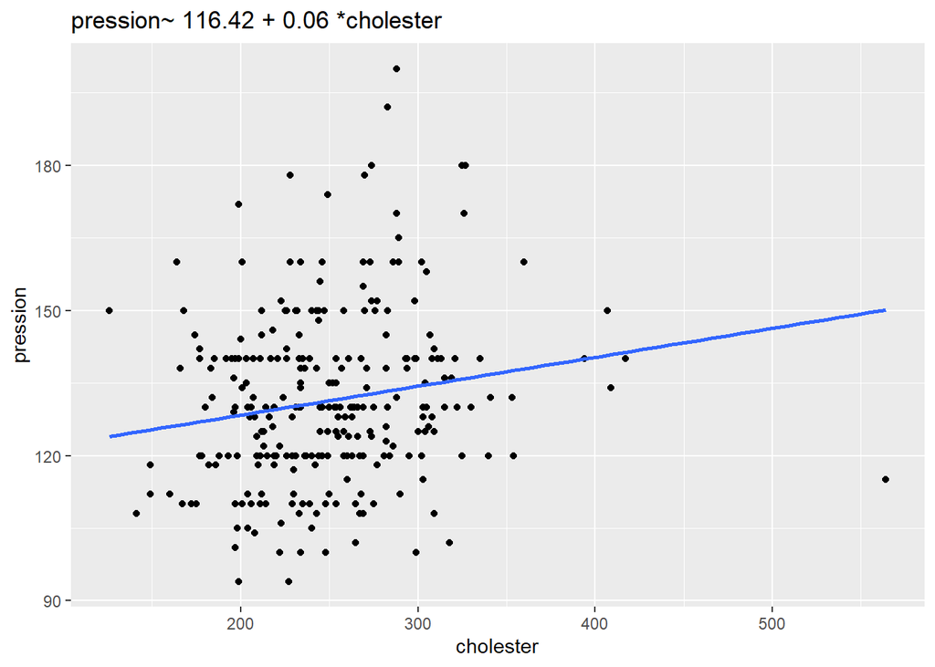

```r
ggplot(db)+aes(x=cholester,y=pression)+geom_point()+stat_smooth(method="lm", se=FALSE)+
  ggtitle(eq2)
```